# STAT0002 Introduction to Probability and Statistics

### Straightening scatter plots

Suppose we have drawn a scatter plot and the general form of the relationship between the variables $y$ and $x$ appears to be monotonic, $y$ tends either to increase or decrease with the value of $x$, subject to some random scatter about this relationships. However, the relationship between the variables $y$ and $x$ is not even approximately a straight line, that is, it is non-linear, rather than linear.

There are two main reasons why we may want to **straighten out** a scatter plot, that is, make it closer to being linear:

- we may be find it easier to appeciate the relationship between variables when that relationship is linear compared to a case where the relationship is non-linear and more complicated;
- we may be hoping to be able to use a simple method of analysis that requires approximate linearity, for example, linear regression @ref(linreg).

#### How can we straighten a scatter plot?

We could transform the $y$ variable, that is, plot a function of $y$ on the $y$-axis. As in Section @ref(transsymmetry), commonly-used transformations are

$$y^3\,, \quad
y^2\,, \quad
(y)\,, \quad
\sqrt{y}\,, \quad
\log y\,, \quad
-\frac{1}{\sqrt{y}}\,, \quad
-\frac1y\,, \quad
-\frac{1}{y^2}\,, \quad
-\frac{1}{y^3}\,, \quad$$

**Question**: Why might we prefer to use the transformation $-1/y$, rather than $1/y$?

If we wish to use transformation to straighten a scatter plot then we have lots of choice about which transformations to try. These days it is easy to use trial-and-error, that is, to try lots of transformations and judge by eye which of the resulting plots we prefer. There are also automatic computational methods to do this. However, before the advent of modern computing, producing plots was more time-consuming and it was helpful to use the shape of the original plot to suggest which transformations might work. One way to do this is sometimes called **Tukey and Mosteller’s bulging rule**.

Consider the curve plotted in Figure @ref(fig:hollowup). Imagine a straight line drawn between the ends of this curve. In the middle of the curve the values of both $y$ and $x$ are smaller than the points on the imaginary line. We say that the curve is bulging down in both the $y$ and $x$ directions.

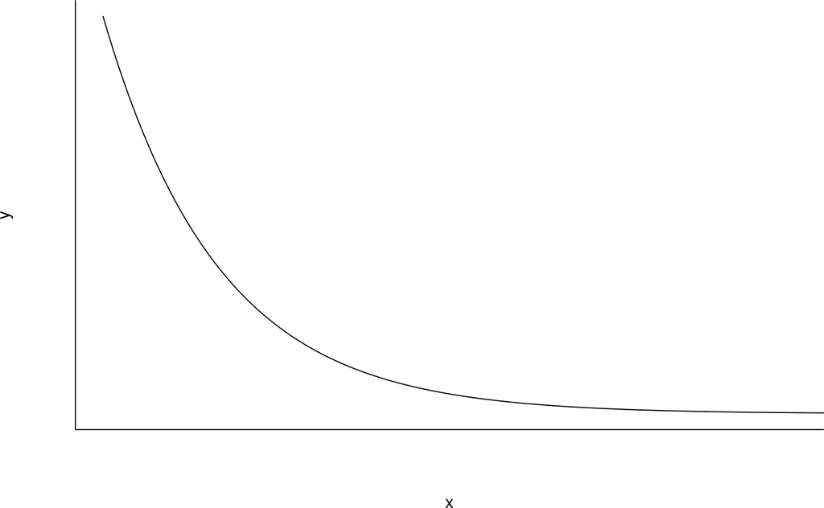

A curve in which both $y$ and $x$ are bulging down compared to an imaginary straight line drawn between the ends of the curve.

Similarly, in Figure @ref(fig:hollowdown) $x$ is bulging down but now $y$ is bulging up.

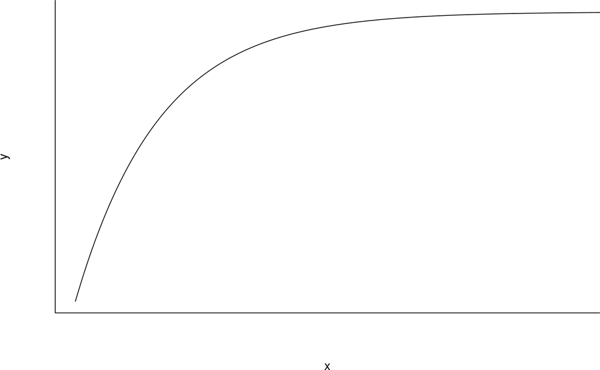

Consider Figure @ref(fig:electionHS1) as an example. The relationship between the variables is similar to the curve in Figure @ref(fig:hollowup). Therefore, we should try transforming $y$ using using a transformation like $\sqrt{y}, \, \log y, \ldots$.

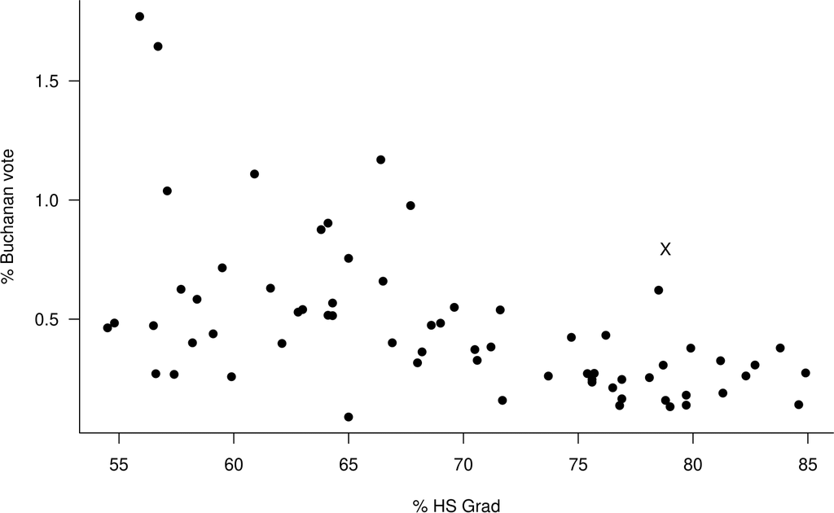

Scatter plot of the percentage of the vote obtained by Buchanan against the percentage of the population who graduate from high school the 2000 US Presidential Election data.

The curvature of the relationship shown in @ref(fig:electionHS1) is not strong, so it makes sense that in Figure @ref(fig:electionHS2) approximately linearity of relationship is acheived using the relatively weak transformation $\sqrt{y}$.

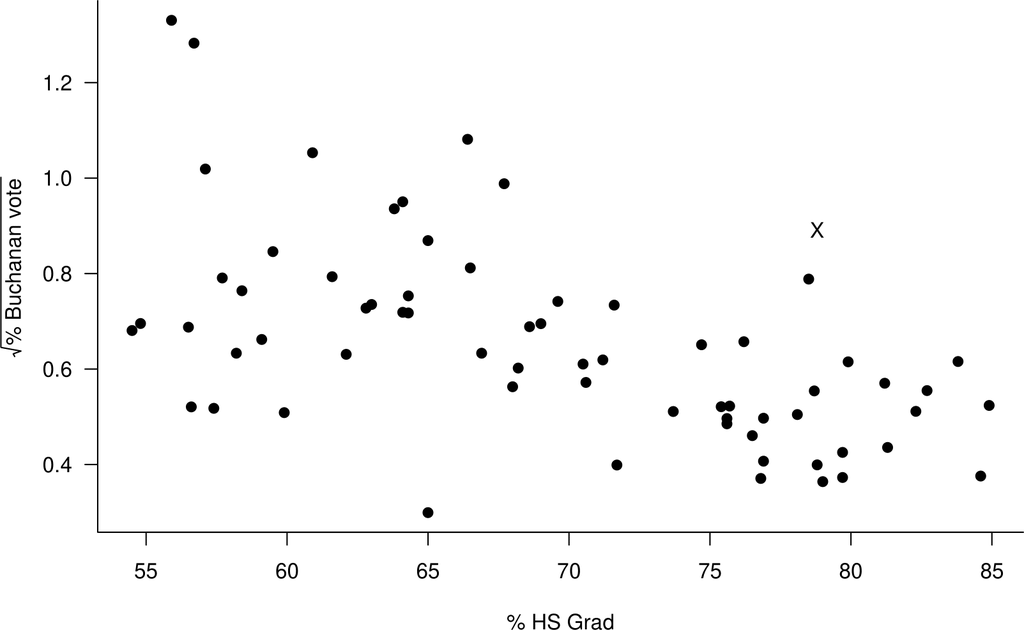

Scatter plot of the square root of the percentage of the vote obtained by Buchanan against the percentage of the population who graduate from high school the 2000 US Presidential Election data.

Figure @ref(fig:tukey) shows how Tukey and Mosteller’s bulging rule works in the four different bulging cases, considering the possibilities of transforming $y$ only, $x$ only or both $y$ and $x$. To use this figure first pick the curve that is relevant to the scatter plot in question. The expressions given at the ends of this curve are examples of the kind of transformations that you could try. The general forms of the indicated transformations are given in the caption to the figure.

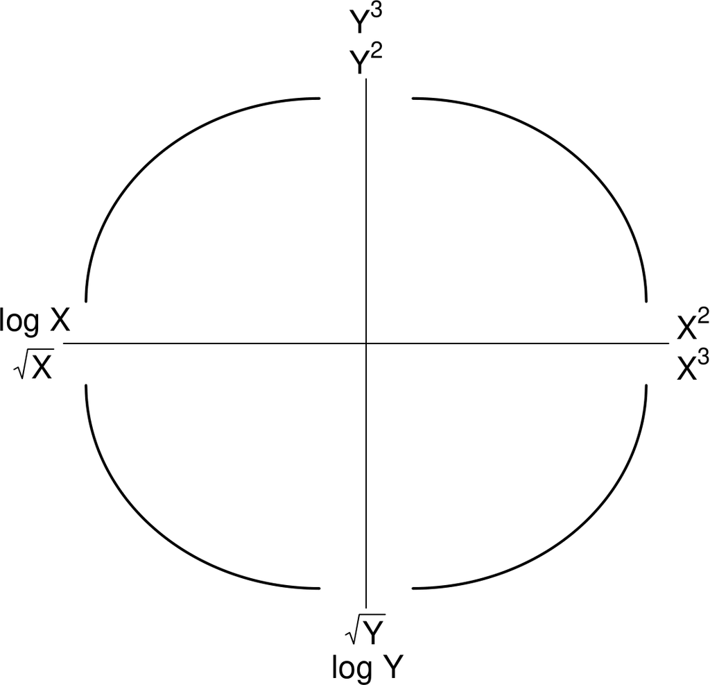

Summary of transformations, of the form $Y^{c_y}$ and/or $X^{c_x}$, to try. Bottom left: $c_y < 1, c_x < 1$. Top left: $c_y > 1, c_x < 1$.Top right: $c_y > 1, c_x > 1$.Bottom right: $c_y < 1, c_x > 1$.

#### Linearity is not the only consideration

Although linearity can be important other things can be important too. Suppose that we draw a ‘line-of-best-fit’ on a scatter plot which looks approximately linear. Figure @ref(fig:electionHS3) is a copy of Figure @ref(fig:electionHS2) with such a line superimposed. In section @ref(linreg) we will see that in a simple linear regression model it is assumed that the amount of (vertical) scatter in the $y$ direction of points about a line of best fit is the same for all values of the explanatory variable $x$.

In Figure @ref(fig:electionHS3) there is perhaps a greater spread of points about the line for small values of % HS Grad than for large values of % HS Grad.

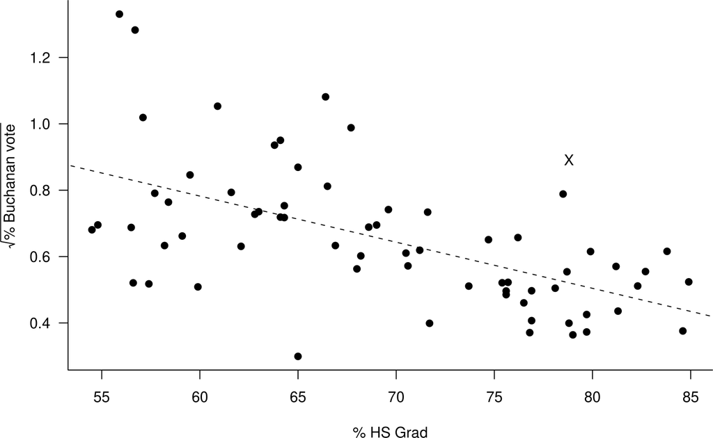

Scatter plot of the square root of the percentage of the vote obtained by Buchanan against the percentage of the population who graduate from high school the 2000 US Presidential Election data. A (dashed) line-of-best-fit is superimposed.

In Section @ref(linregtrans) we consider how to use transformation of $y$ and/or $x$ to satisfy better the assumptions of a linear regression model.

# Probability

Most people have heard the word **probability** used in connection with a random experiment, that is, an experiment whose outcome cannot be predicted with certainty, such as tossing a coin, tossing dice, dealing cards etc. We start by considering a criminal case in which fundamental ideas surrounding the use of probability were hugely important. Then we study the concept of probability using the traditional simple example of tossing a coin.

## Misleading statistical evidence in cot death trials

In recent years there have been three high-profile criminal cases in which a mother has been put on trial for the murder of a her babies. In each case the medical evidence against the woman was weak and the prosecution relied heavily on statistical arguments to make their case. However, these arguments were not made by a statistician, but by a medical expert witness: Professor Sir Roy Meadows. However, there were two problems with Professor Meadows’ evidence: firstly, it contained serious statistical errors; and secondly, it was presented in a way which is likely to be misinterpreted by a jury. To illustrate the error we consider the case of Sally Clark.

Sally Clark’s first child died unexpectedly in 1996 at the age of 3 months. Sally was the only person in the house at the time. There was evidence of a respiratory infection and the death was recorded as natural; a case of **Sudden Infant Death Syndrome (SIDS)**, or **cot death**. In 1998 Sally’s second child died in similar circumstances at the age of 2 months. Sally was then charged with the murder of both babies. There was some medical evidence to suggest that the second baby could have been smothered, although this could be explained by an attempt at resuscitation.

It appeared that the decision to charge Sally was based partly on the reasoning that cot death is quite rare so having two cot deaths in the same family must be very unlikely indeed. This is the basis of Professor Meadows’ assertion that: “One cot death is a tragedy, two cot deaths is suspicious and, until the contrary is proved, three cot deaths is murder.”. At her trial in 1999 Sally Clark was found guilty of murder and sentenced to life imprisonment.

#### Professor Meadows’ statistical evidence

At Sally Clark’s trial in 1999 Professor Meadows claimed that, in a family like Sally’s (affluent, non-smoking with a mother aged over 26), the chance of two cot deaths is 1 in 73 million, that is, a probability of 1/73,000,000 $\approx$ 0.000000014. Professor Meadows had calculated this value based on a study which had estimated the probability of one cot death in a family like Sally’s to be 1 in 8543, that is, 1 cot death occurs for every 8543 of such families.

Professor Meadows had then performed the calculation
$$\frac{1}{8543}\times\frac{1}{8543}=\frac{1}{72,982,849}\approx\frac{1}{73,000,000}.$$

There are problems with this evidence, both with this calculation and with the idea that this apparently small number provides evidence of guilt.

Can you identify these problems?

## Relative frequency definition of probability

#### Example: tossing a coin

If you toss a coin, the outcome (the side on top when the coin falls to the ground) is either a Head ($H$) or a Tail ($T$). Suppose that you toss the coin a large number of times. Unless you are very skillful the outcome of each toss depends on chance. Therefore, if you toss the coin repeatedly, the exact sequence of $H$s and $T$s is not predictable with certainty in advance. This is usually the case with any experiment. Even if we try very hard to repeat an experiment under exactly the same conditions, there is a certain amount of variability in the results which we cannot explain, but we must accept. The experiment is a **random experiment**.

Nevertheless, if the coin is fair (equally balanced), and it is tossed fairly, we might expect the long run **proportion**, or **relative frequency**, of $H$s to settle down to 1/2. However, the only way to find out whether this is true is to toss a coin repeatedly, forever, and calculate the proportion of tosses on which $H$ is the outcome. It is not possible, in practice, for any experiment to be repeated forever.

However, a South African statistician Jon Kerrich managed to toss a coin 10,000 times while imprisoned in Denmark during World War II. At the end of his effort he had recorded 5067 Heads and 4933 Tails. Figure @ref(fig:coin) shows how the proportion of heads Kerrich threw changed as the number of tosses increased.

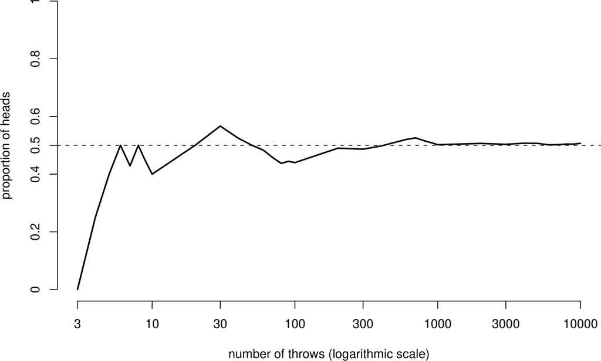

The proportion of heads in a sequence of 10,000 coin tosses. Kerrich (1946).

Initially the proportion of heads fluctuates greatly but begins to settle down as the number of tosses increases. After 10,000 tosses the relative frequency of Head is 5067/10,000=0.5067. We might suppose that if Kerrich were able to continue his experiment forever, the proportion of heads would tend to a limiting value which would be very near, if not exactly, 1/2. This hypothetical limiting value if the probability of heads and is denoted by $P(H)$.

#### Looking at this slightly more formally

The coin-tossing example motivates the **relative frequency** or **frequentist** definition of the probability of an event; namely

> the relative frequency with which the event occurs in the long run;

or, in other words,

> the proportion of times that the event would occur in an infinite number of identical repeated experiments.

Suppose that we toss a coin $n$ times. If the coin is fair, and is tossed fairly, then it is reasonable to suppose that
$$\mbox{the relative frequency of $H$} \,\,=\,\,
\frac{\mbox{number of times $H$ occurs}}{n},$$
tends to 1/2 as $n$ gets larger. We say that the event $H$ has probability 1/2, or $P(H)=1/2$.

More generally, consider some event $E$ based on the outcomes of an experiment. Suppose that the experiment can, in principle, be repeated, under exactly the same conditions, forever. Let $n(E)$ denote the number of times that the event $E$ would occur in $n$ experiments.

We suppose that
$$\mbox{the relative frequency of $E$} \,=\,
\frac{n(E)}{n} \,\longrightarrow\, P(E)\,, \,\, \mbox{~as~}n \longrightarrow \infty.$$
So, the probability $P(E)$ of the event $E$ is defined as the limiting value of $n(E)/n$ as $n \rightarrow \infty$. That is,
$$\begin{equation}
P(E) \,\,=\,\, \mathop {\rm limit}\limits_{n \rightarrow \infty}\,\frac{n(E)}{n},
(\#eq:limit)
\end{equation}$$
supposing that this limit exists. (Note: I have written ‘limit’ and not ‘lim’ because this is not a limit in the usual mathematical sense.)

In order to satisfy ourselves that the probability of an event **exists**, we do not need to repeat an experiment an infinite number of times, or even be able to. All we need to do is **imagine** the experiment being performed repeatedly. An event with probability 0.75, say, would be expected to occur 75 times out of 100 in the long run.

An alternative approach, considered in STAT0003, makes a simple set of basic assumptions about probability, called the **axioms of probability**. Using these axioms it can be proved that the limiting relative frequency in equation @ref(eq:limit) does exist and that it is equal to $P(E)$. In STAT0002 we will not consider these axioms formally. However, they are so basic and intuitive that you will find that we take them for granted.

**An aside**. There is another definition of probability, the **subjective** definition, which is the degree of belief someone has in the occurrence of an event, based on their knowledge and any evidence they have already seen. For example, you might reasonably believe that the probability that a coin comes up Heads when it is tossed is 1/2 because the coin looks symmetrical. If you are **certain** that $P(H)=1/2$ then no amount of evidence from actually tossing the coin will change your mind. However, if you just think that $P(H)=1/2$ is more likely that other values of $P(H)$ then observing many more $H$s than $T$s in a long sequence of tosses may lead you to believe that $P(H)>1/2$. We will not consider this definition of probability again in this course. However, it forms the basis of the **Bayesian** approach to Statistics. You may study this in a more advanced courses, for example, STAT0008 Statistical Inference.

#### Example: tossing a coin (continued)

We now look at the coin-tossing example in a slightly different way. If we toss a coin forever we generate an infinite **population** of **outcomes**: {H,H,T,H,}, say. Think about choosing, or **sampling**, one of these outcomes at random from this population. The probability that this outcome is $H$ is the proportion of $H$s in the population. If we **assume** that the coin is fair then the infinite population contains 50% $H$s and 50% $T$s. In that case $P(H)=1/2$, and $P(T)=1/2$.

#### Example: Graduate Admissioins at Berkeley

Table @ref(tab:berk0) contains data relating to graduate admissions in 1973 at the University of California, Berkeley, USA in the six largest (in terms of numbers of admissions) departments of the university. These data are discussed in Bickel, Hammel, and O’Connell (1975). We use the following notation: $A$ for an accepted applicant, $R$ for a rejected applicant. Table @ref(tab:berk0n) summarises the notation used for the frequencies in Table @ref(tab:berk0). For example, $n(A)$ denotes the number of applicants who were accepted. We will look at this example in more detail later.

(#tab:berk0) Numbers of graduate applicants by outcome.

| A | R | total |
| --- | --- | --- |
| 1755 | 2771 | 4526 |

(ref:berk0n-caption) Notation for Table @ref(tab:berk0).

(#tab:berk0n) (ref:berk0n-caption)

| A | R | total |
| --- | --- | --- |
| n(A) | n(R) | n |

The population of interest now is the population of graduate applicants to the six largest departments of the Berkeley. If we choose an applicant at random from this population the probability $P(A)$ that they are accepted is given by
$$P(A) = \frac{n(A)}{n} = \frac{1,755}{4,526} = 0.388.$$
Similarly, the probability $P(R)$ that a randomly chosen applicant is rejected is given by
$$P(R) = \frac{n(R)}{n} = \frac{2,771}{4,526} = 0.612.$$

In both the coin-tossing and Berkeley admissions examples we have imagined choosing an individual from a population in such a way that all individuals are equally likely to be chosen. The probability of the individual having a particular property, for example, that an applicant is accepted, is given by the proportion of individuals in the population which have this property.

In the coin-tossing example the population is hypothetical, generated by thinking about repeating an experiment an infinite number of times. In the Berkeley admissions example the population is an actual population of people.

#### Notation: sample space, outcomes and events

The set of all possible outcomes of a random experiment is called the **sample space** $S$ of the experiment. We may denote a single **outcome** of an experiment by $s$. An **event** $E$ is a collection of outcomes, possible just one outcome.

It is very important to define the sample space $S$ carefully. In the coin-tossing example we have $S=\{H,T\}$. If the coin is unbiased then the probabilities of the outcomes in $S$ are given by $P(H)=1/2$ and $P(T)=1/2$.

## Basic properties of probability

Since we have defined probability as a proportion, basic properties of proportions must also hold for a probability. Consider an event $E$. Then the following must hold

- $0 \leq P(E) \leq 1$;
- if $E$ is impossible then $P(E)=0$;
- if $E$ is certain then $P(E)=1$;
- $P(S)=1$. This is true because the outcome must, by definition, be in the sample space.

## Conditional probability

In Section @ref(sids) the statistical evidence presented to the court was based on the estimate that “the probability of one cot death **in a family like Sally Clark’s** is 1 in 8543”. What does this mean?

The study from which this statistic was taken estimated the **overall** probability of cot death to be 1 in 1303. That is, cot death occurs in approximately 1 in every 1303 families.

However, the study also found that the probability of cot death depended on various characteristics such as, income, smoking status and the age of the mother. For example, the probability of cot death was found to be much greater in families containing one or more smokers than in non-smoking families.

The study estimated the probability of cot death for each possible combination of these characteristics. For the combination which is relevant to Sally Clark, whose family was affluent, non-smoking and she was aged over 26, the probability of cot death was estimated to be smaller: 1 in 8543.

This (1 in 8543) is a **conditional** probability. We have **conditioned** on the event that the family in question is affluent, non-smoking and the mother is aged over 26. The overall probability of cot death (1 in 1303) is often called an **unconditional** probability.

In this example it is perhaps easiest to think of the conditioning as selecting a specific sub-population of families from the complete population of families. Another way to think about this is in terms of the sample space. We have reduced the original sample space - the outcomes (cot death or no cot death) of all families with children - to a subset of this sample space - the outcomes of all affluent, non-smoking families where the mother is over 26.

#### Notation

When we are working with conditional probabilities we need to use a neat notation rather than write out long sentences like the ones above.

Let $C$ be the event that a family has one cot death. Let $F_1$ be the event that the family in question is affluent, non-smoking, and the mother is over 26. Instead of writing “the probability of one cot death in a family conditional on the type of family is 1 in 8543”" we write
$$P(C \mid F_1) = \frac{1}{8543}.$$
The `$\mid$’ sign means **“conditional on”**’ or, more simply, **“given”**. Therefore, for $P(C \mid F_1)$ we might say "“the probability of event $C$ conditional on event $F_1$”, or “the probability of event $C$ given event $F_1$”.

The (unconditional) probability of one cot death is given by
$$P(C) = \frac{1}{1303}.$$

In section @ref(sids) I did not use the $~\mid~$ sign in my notation (because we hadn’t seen it then), but I did make the conditioning clear by saying **for a family like Sally Clark’s**. ]

In fact **all** probabilities are conditional probabilities, because a probability is conditioned on the sample space $S$. When we define $S$ we rule out anything that is not in $S$. So instead of $P(C)$ we could write $P(C \mid S)$. We do not tend to do this because it takes more time and it tends to make things more difficult to read. However, we should always try to bear in mind the sample space when we think about a probability.

We return to the Berkeley admissions example to illustrate conditional probability, independence and the rules of probability.

#### Example: Graduate Admissions at Berkeley (continued)

Table @ref(tab:berk1) contains more information on data relating to graduate admissions in 1973 at Berkeley in the six largest (in terms of numbers of admissions) departments of the university.

We use the following notation: $M$ for a male applicant, $F$ for a female applicant, $A$ for an accepted applicant, $R$ for a rejected applicant. This is an example of a 2-way contingency table (see Section @ref(contingency)).

(#tab:berk1) Numbers of graduate applicants by sex and outcome.

|  | A | R | total |
| --- | --- | --- | --- |
| M | 1198 | 1493 | 2691 |
| F | 557 | 1278 | 1835 |
| total | 1755 | 2771 | 4526 |

Table @ref(tab:berk1n) summarises the notation used for the frequencies in Table @ref(tab:berk1). For example, $n(M, A)$ denotes the number of applicants who were both male and accepted. Of course, $n(M, A)=n(A, M)$.

(ref:berk1n-caption) Notation for Table @ref(tab:berk1).

(#tab:berk1n) (ref:berk1n-caption)

|  | A | R | total |
| --- | --- | --- | --- |
| M | n(M, A) | n(M, R) | n(M) |
| F | n(F, A) | n(F, R) | n(F) |
| total | n(A) | n(R) | n |

If we divide each of the numbers in Table @ref(tab:berk1) by the total number of applications ($n$ = 4526) then we obtain the proportions of applicants in each of the four categories. These proportions are given (to 3 decimal places) in Table @ref(tab:berk2p).

(ref:berk2p-caption) Proportions based on Table @ref(tab:berk1).

(#tab:berk2p) (ref:berk2p-caption)

|  | A | R | total |
| --- | --- | --- | --- |
| M | 0.265 | 0.330 | 0.595 |
| F | 0.123 | 0.282 | 0.405 |
| total | 0.388 | 0.612 | 1.000 |

Table @ref(tab:berk2pn) summarises the notation used for the probabilities in Table @ref(tab:berk2p).

(ref:berk2np-caption) Notation for Table @ref(tab:berk2p).

(#tab:berk2pn) (ref:berk2np-caption)

|  | A | R | total |
| --- | --- | --- | --- |
| M | P(M, A) | P(M, R) | P(M) |
| F | P(F, A) | P(F, R) | P(F) |
| total | P(A) | P(R) | 1 |

For example, the

- probability $P(M)$ that a randomly chosen applicant is male is 0.595; and
- probability $P(M, A)$, or $P(M \mbox{ and } A)$, or $P(M \cap A)$, or even $P(MA)$, that a randomly chosen applicant is both male and accepted is 0.265.

In the second bullet point four different forms of notation are used to denote the same probability. In these notes I may (deliberately, of course) use more than one form of notation, to get you used to the fact that different texts may use different notation. Of course, $P(M, A) = P(A, M)$ and so on.

The following explains how these probabilities are calculated.

$$P(M) = \frac{n(M)}{n} = \frac{2,691}{4,526} = 0.595.$$
The sample space is $\{M,F\}$.

$$P(M , A) = \frac{n(M , A)}{n} = \frac{1,198}{4,526} = 0.265.$$
The sample space is $\{(M , A),(M , R),(F , A),(F , R)\}$.

Suppose that we wish to investigate whether there appears to be any sexual discrimination in the graduate admissions process at Berkeley in 1973. To do this we might compare

- the probability of acceptance for males, that is, $P(A \mid M)$; and
- the probability of acceptance for females, that is, $P(A \mid F)$.

These are **conditional** probabilities. Firstly, we calculate $P(A \mid M)$. Look at Table @ref(tab:berk3n). We are considering only male applicants ($M$) so we have shaded the $M$ row. Since we are conditioning on $M$, female applicants are not relevant. We are only concerned with the $n(M)=2691$ male applicants in the $M$ row.

(#tab:berk3n) Conditioning on applicant being male (frequencies).

|  | A | R | total |
| --- | --- | --- | --- |
| M | 1198 | 1493 | 2691 |
| F | 557 | 1278 | 1835 |
| total | 1755 | 2771 | 4526 |

Of these, $n(M , A) = 1198$ are accepted and $n(M , R) = 1493$ are rejected.

The information that the applicant is male (that is, event $M$ has occurred) has reduced the sample space to $\{(M , A),(M , R)\}$, or, since we **know** that $M$ has occurred, the sample space is effectively $\{A,R\}$. The conditional probability of $A$ given $M$ is the probability that event $A$ occurs when we consider only those occasions on which event $M$ occurs.

Therefore,
$$\begin{equation}
P(A \mid M) = \frac{n(A, M)}{n(M)} = \frac{1198}{2691} = 0.445,
(\#eq:freqs)
\end{equation}$$
that is, the proportion of male applicants who are accepted is 0.445.

Now look at Table @ref(tab:berk3p).

(#tab:berk3p) Conditioning on applicant being male (probabilities).

|  | A | R | total |
| --- | --- | --- | --- |
| M | 0.265 | 0.330 | 0.595 |
| F | 0.123 | 0.282 | 0.405 |
| total | 0.388 | 0.612 | 1.000 |

An equivalent way to calculate $P(A~|~M)$ is

$$\begin{equation}
P(A \mid M) = \frac{P(A, M)}{P(M)} = \frac{1198/4526}{2691/4526} = 0.445. (\#eq:probs)
\end{equation}$$
Instead of using the frequencies in the shaded $M$ row, we have used the probabilities. We get exactly the same answer because the probabilities are simply the frequencies divided by 4526.

**Exercise**. Show that $P(A \mid F)=0.304$.

**Exercise**. Find $P(R \mid M)$ and $P(R \mid F)$. What do you notice about $P(A \mid M)$ and $P(R \mid M)$?}

The calculation of $P(A~|~M)$ in equation @ref(eq:freqs) based on the frequencies in Table @ref(tab:berk3n) should make sense to you. From the equivalent calculation in equation @ref(eq:probs) we can see that the following definition of conditional probability makes sense.

**Definition**. If $B$ is an event with $P(B) > 0$, then for each event $A$, the **conditional probability of $A$ given $B$** is
$$\begin{equation}
P(A \mid B)=\frac{P(A , B)}{P(B)}.
(\#eq:conditional)
\end{equation}$$
Remarks:

- It is necessary that $P(B) > 0$ for $P(A \mid B)$ to be defined. It does not make sense to condition on an event that is impossible.
- Equation @ref(eq:conditional) implies that $P(A , B) = P(A \mid B)\,P(B)$.
- For any event $A$, $P(A \mid B)$ is a probability in which the sample space has been reduced to outcomes containing the event $B$. Therefore, **all** properties of probabilities also hold for conditional probabilities, e.g. $0 \leq P(A~|~B) \leq 1$.

#### Dependence and Independence

We return to the Berkeley example. We have found that
$$P(A \mid M) = 0.445 \qquad \mbox{and} \qquad P(A~|~F) = 0.304.$$
From Table @ref(tab:berk2p) we find that
$$P(A) = 0.388.$$
Therefore, the probability of acceptance depends on the sex of the applicant:
$$P(A \mid M) > P(A) \qquad \mbox{and} \qquad P(A \mid F) < P(A).$$
The probability $P(A \mid M)$ of being accepted for a randomly selected male is greater than the unconditional probability $P(A)$. Therefore, the occurrence of event $M$ has affected the probability that event $A$ occurs. This means that the events $A$ and $M$ are **dependent**. Similarly, $P(A \mid F) < P(A)$ means that the events $A$ and $F$ are **dependent**.

We consider independent and dependent events in more detail in Section @ref(indepevents).

The fact that $P(A~|~M) > P(A~|~F)$ might suggest to us that there is gender bias in the admissions process. However, as we shall see in Section @ref(way3), this may be a very misleading conclusion to draw from these data. There is an innocent explanation of why $P(A \mid M) > P(A \mid F)$.

**Exercise**. Can you think what this innocent explanation it might be?

## Addition rule of probability

We continue with the Berkeley admissions data. Suppose that we wish to calculate the probability that an applicant chosen at random from the 4526 applicants is either male (event $M$) or accepted (event $A$), or both male and accepted. We denote this probability $P(M \mbox{ or } A)$ or $P(M \cup A)$.

Look at Table @ref(tab:berk4n). The cells that satisfy either $M$ or $A$, or both, have been shaded grey. To calculate $P(M \mbox{ or } A)$ we simply sum the numbers of applicants for which either $M$ or $A$, or both, is satisfied and then divide by $n=4526$, that is,

$$\begin{eqnarray}
P(M \mbox{ or } A) &=& \frac{n(M \mbox{ or } A)}{n} \nonumber \\
&=& \frac{n(M , A)+n(M , R)+n(F , A)}{n} \nonumber \\
&=& \frac{1198+1493+557}{4526} = \frac{3248}{4526} = 0.718.
\end{eqnarray}$$

(#tab:berk4n) Cells with M or A are shaded (frequencies).

|  | A | R | total |
| --- | --- | --- | --- |
| M | 1198 | 1493 | 2691 |
| F | 557 | 1278 | 1835 |
| total | 1755 | 2771 | 4526 |

An equivalent way to calculate $P(M \mbox{ or } A)$ is to sum probabilities in Table @ref(tab:berk4p), that is,

$$\begin{eqnarray}
P(M \mbox{ or } A) &=& P(M \mbox{ and } A) + P(M \mbox{ and }R) + P(F \mbox{ and } A) \\
&=& 0.265+0.330+0.123 = 0.718.
\end{eqnarray}$$

(#tab:berk4p) Cells with M or A are shaded (probabilities).

|  | A | R | total |
| --- | --- | --- | --- |
| M | 0.265 | 0.330 | 0.595 |
| F | 0.123 | 0.282 | 0.405 |
| total | 0.388 | 0.612 | 1.000 |

**Exercise**. Can you see why these two calculations are equivalent?

**Exercise**. Can you see a (slightly) quicker way to calculate $P(M \mbox{ or } A)$?

Now consider a slightly different way to show that $n(M \mbox{ or } A)=3248$:
$$n(M \mbox{ or } A) = n(M) + n(A) - n(M, A) = 2691 + 1755 - 1198 = 3248.$$

Can you see from Table @ref(tab:berk4n) why this works?

Similarly,
$$P(M \mbox{ or } A) = P(M) + P(A) - P(M \mbox{ and } A) = 0.595 + 0.388 - 0.265 = 0.718.$$

From this example we can see that following rule makes sense.

**Definition**. For any two events $A$ and $B$
$$\begin{equation}
P(A \mbox{ or } B) = P(A) + P(B) - P(A \mbox{ and } B).
(\#eq:ordef)
\end{equation}$$

### Mutually exclusive events

Two events $A$ and $B$ are **mutually exclusive** (or **disjoint**) if they cannot occur together. For example, in the Berkeley example the events $A$ and $R$ are mutually exclusive: it is not possible for an applicant to be both accepted and rejected.

If two events $A$ and $B$ are mutually exclusive then $P(A \mbox{ and } B)=0$. Substituting this into equation @ref(eq:ordef) we find that, **if events $A$ and $B$ are mutually exclusive**
$$\begin{equation}
P(A \mbox{ or } B) = P(A) + P(B).
(\#eq:mut)
\end{equation}$$
You can only use this equation in the **special case** where events $A$ and $B$ are mutually exclusive. Otherwise, you must use the general rule in equation @ref(eq:ordef).

#### The complement of an event $A$

The **complement** of an event $A$ is the event that $A$ does not occur. This can be denoted $\mbox{not}A$ or $\bar{A}$ or $A^c$. The events $A$ and $\mbox{not}A$ are mutually exclusive and $S=\{A, \mbox{not}A\}$. We have already seen that $P(S) = 1$. Therefore,
$$P(S)=P(A \mbox{ or } \mbox{not}A) = P(A) + P(\mbox{not}A) = 1.$$
and therefore
$$P(\mbox{not}A) = 1 - P(A).$$

## Multiplication rule of probability

We continue with the Berkeley admissions data. We have already calculated that $P(M , A)=0.265$. Now we calculate this in a different way.

Think about the process of applying for a place at university. First an applicant makes an application. Then the university decides whether to accept or reject. To have the event $(M, A)$ we first need a male applicant to apply and then for the university to accept them.

The calculation we performed above was
$$P(M , A) = \frac{n(M , A)}{n}.$$
Assuming that $n(M)>0$, that is, $P(M)>0$, we can rewrite this as
$$P(M , A) = \frac{n(M)}{n} \times \frac{n(M , A)}{n(M)} = \frac{n(M)}{n} \times \frac{n(A , M)}{n(M)},$$
or
$$P(M , A) = P(M) \times P(A \mid M).$$
Firstly, we calculate the proportion of applicants who are male, and then the proportion of those male applicants who are accepted. Multiplying these proportions gives the overall proportion of applicants who are both male and accepted.

This also follows directly on rearrangement of the definition,
$$P(A \mid M) = \frac{P(M , A)}{P(M)}.$$

**Definition**. Consider two events $A$ and $B$ with $P(B)>0$. Rearranging the definition of conditional probability @ref(eq:conditional) gives
$$\begin{equation}
P(A , B) = P(B)\,P(A \mid B).
(\#eq:mult)
\end{equation}$$

This can be generalised to the case of $n$ events to give
$$\begin{eqnarray}
P(A_1, A_2,\ldots, A_{n-1}, A_n) &=&
P(A_1)\,P(A_2~|~A_1)\,P(A_3~|~A_1,A_2)\,\cdots\,P(A_n~|~A_{n-1},\ldots,A_1),
\end{eqnarray}$$
provided that all the conditional probabilities are defined. A sufficient (but not necessary) condition for this is $P(A_1, A_2, \ldots, A_{n-1}, A_n)>0$. For example, $P(A_1, A_2, A_3)$ is the probability that events $A_1$, $A_2$ and $A_3$ all occur.

## Independence of events

**Definition**. Two events $A$ and $B$ are **independent**
$$\begin{equation}
P(A , B) = P(A) \,P(B).
(\#eq:indep)
\end{equation}$$
Otherwise $A$ and $B$ are dependent events.

Remarks:

1. If $P(A) > 0$ and $P(B) > 0$, then independence of $A$ and $B$ implies
   $$P(A \mid B) = \frac{P(A , B)}{P(B)} = \frac{P(A)\,P(B)}{P(B)} = P(A)$$
   and similarly $P(B~|~A)=P(B)$.
2. The definition applies for events that have zero probability. For example, suppose that $P(A)>0$ and $P(B)=0$. Then $A$ and $B$ are independent because
   $$P(A , B) = 0 = P(A)\,P(B).$$
3. The definition is symmetric in $A$ and $B$. If $A$ is independent of $B$, then $B$ is independent of $A$.
4. Notation: the notation $A \perp \!\!\! \perp B$ can be used for “$A$ and $B$ are independent”.
5. The definition of independence can be extended to more than two events. $A_1, A_2, \ldots, A_n$ are (mutually) independent if, for $r \in \{2, \ldots, n\}$, for any subset $\{ C_1, \ldots, C_r \}$ of $\{ A_1, \ldots, A_n\}$ we have
   $$P(C_{1} , C_{2} , \cdots C_{r}) = P(C_{1}) P(C_{2}) \cdots P(C_{r}).$$
   For example, if $n = 3$ then we need
   $$P(A_{1} , A_{2}) = P(A_1) P(A_2), \,\, P(A_{1} , A_{3}) = P(A_1) P(A_3), \,\, P(A_{2} , A_{3}) = P(A_2) P(A_3)$$
   that is, $(A_1, A_2, A_3)$ are pairwise independent, and
   $$P(A_{1} , A_{2} , A_{3}) = P(A_{1}) P(A_{2}) P(A_{3}).$$

### An example of independence

The 2 most important systems for classifying human blood are the ABO system, with blood types A, B, AB and O, and the Rhesus system, with blood types Rh+ and Rh-. In the ABO system an A (and/or B) indicates the presence of antigen A (and/or B) molecules on the red blood cells. These two systems are often combined to form 8 blood types A+, B+, AB+, O+, A–, B–, AB– and O–. Knowledge of blood type is important when a patient needs a blood transfusion.Giving blood of the wrong type can cause harm: giving Rh+ blood to someone who is Rh– will make that person ill, as will giving blood with a A or B antigens to someone without those antigens. An AB+ person can receive blood from anyone, but an O– person can only receive O- blood.

The proportions of blood types varies between countries. In the UK the percentages for the ABO system are estimated to be equal to those in Table @ref(tab:bloodABO). Table @ref(tab:bloodrhesus) gives the percentages for the Rhesus system.

(#tab:bloodABO) Distribution of ABO blood groups in the UK.

| ABO group | percentage |
| --- | --- |
| O | 44 |
| A | 42 |
| B | 10 |
| AB | 4 |

(#tab:bloodrhesus) Distribution of Rhesus blood groups in the UK.

| Rhesus group | percentage |
| --- | --- |
| Rh+ | 83 |
| Rh- | 17 |

These tables tell us that, for the UK, $P(\mbox{O})=0.44, P(\mbox{A})=0.42, P(\mbox{B})=0.1, P(\mbox{AB})=0.04$, $P(\mbox{Rh}+)=0.83$ and $P(\mbox{Rh}-)=0.17$.

Your blood type is genetically inherited from your parents. Since the genetic code responsible for inheritance of ABO blood group and Rhesus blood group are on different chromosomes, ABO and Rhesus blood types are inherited independently of each other. That is, for any person, the blood type in the ABO system is independent of their blood type in the Rhesus system.

Assuming that ABO blood type is independent of Rhesus blood type gives the probabilities in Table @ref(tab:bloodindep). Some of these probabilities have been omitted.

(#tab:bloodindep) Distribution of Rhesus blood groups in the UK.

|  | O | A | B | AB | total |
| --- | --- | --- | --- | --- | --- |
| Rh+ |  | 0.349 | 0.083 |  | 0.830 |
| Rh- | 0.075 | 0.071 | 0.017 |  | 0.170 |
| total | 0.440 | 0.420 | 0.100 | 0.040 | 1.000 |

**Exercise**. Using equation @ref(eq:indep), or otherwise, calculate the values that are missing from Table @ref(tab:bloodindep).

## Law of total probability

We continue with the Berkeley admissions data. We have already calculated that $P(A)=0.388$. Now we calculate this in a different way.

Note that

- $M$ and $F$ are mutually exclusive events.
- $P(M \mbox{ or } F) = 1$, that is, together $M$ and $F$ make up the entire sample space of the possible values of sex. This means that $M$ and $F$ are **exhaustive** events.

**Definition**. **The law of total probability**. Let events $B_1,\ldots,B_n$ be

- possible, i.e. $P(B_i) > 0$, for $i = 1, \ldots, n$,
- mutually exclusive, i.e. $P(B_i , B_j)=0$ for $i \neq j$, and
- exhaustive, that is, $P(B_1 \mbox{ or } B_2 \mbox{ or } \cdots \mbox{ or } B_n) = 1$.

Then, for any event $A$
$$\begin{eqnarray}
P(A) &=& P(A \mid B_1)\,P(B_1) + \cdots + P(A \mid B_n)\,P(B_n), \\
&=& \displaystyle\sum_{i=1}^n P(A \mid B_i)\,P(B_i). \\
\end{eqnarray}$$

Some books refer to the law of total probability as the **partition theorem**. This is because events $B_1, \ldots, B_n$ that are both mutually exclusive and exhasutive are said to **partition** the sample space, that is, they split the sample space into $n$ disjoint parts.

## Bayes’ theorem

We continue with the Berkeley admissions data. We have already calculated that $P(A \mid M) = 0.445$. Now we calculate $P(M \mid A)$. It is important that you understand the difference between these two probabilities.

$P(A \mid M)$ is the probability of acceptance given that the applicant is male; in other words, the probability that a male applicant is accepted. We calculated that $P(A \mid M)=0.445$ using the $M$ row of Table @ref(tab:berk3n) (or Table @ref(tab:berk3p)), that is, by conditioning on the event $M$.

$P(M \ldots A)$ is the probability that the applicant is male given that they are accepted; in other words, the probability that an accepted applicant is male.

**Exercise**. Use Table @ref(tab:berk5n) or Table @ref(tab:berk5p) to show that $P(M \mid A) = 0.683$.

(#tab:berk5n) Conditioning on applicant being accepted (frequencies).

|  | A | R | total |
| --- | --- | --- | --- |
| M | 1198 | 1493 | 2691 |
| F | 557 | 1278 | 1835 |
| total | 1755 | 2771 | 4526 |

(#tab:berk5p) Conditioning on applicant being accepted (probabilites).

|  | A | R | total |
| --- | --- | --- | --- |
| M | 0.265 | 0.330 | 0.595 |
| F | 0.123 | 0.282 | 0.405 |
| total | 0.388 | 0.612 | 1.000 |

Now we calculate $P(M \mid A)$ in a different way. If you used table @ref(tab:berk5p) to calculate $P(M \mid A)$ you used the equation
$$\begin{equation}
P(M \mid A) = \frac{P(M , A)}{P(A)}.
(\#eq:bayes1)
\end{equation}$$
The multiplication rule in Section @ref(multrule) gives
$$\begin{equation}
P(M , A) = P(A~|~M)\,P(M).
(\#eq:bayes2)
\end{equation}$$
Substituting @ref(eq:bayes1) into @ref(eq:bayes2) gives
$$\begin{equation}
P(M \mid A) = \frac{P(A \mid M)\,P(M)}{P(A)}.
(\#eq:bayes3)
\end{equation}$$
Equation @ref(eq:bayes3) is an example of Bayes’ theorem, which was first derived in a paper presented to the Royal Society in 1763 by Richard Price on behalf of the late Reverend Thomas Bayes.

In this example we can either calculate $P(A)$ using the law of total probability:
$$P(A) = P(A \mid M)\,P(M) + P(A \mid F)\,P(F),$$
or calculate $P(A)$ directly from the table.

**Bayes’ theorem**. Let $B_1, \ldots, B_n$ be mutually exclusive, exhaustive events, with $P(B_i) > 0$ for all $i$. Let $A$ be an event with $P(A) > 0$. Then
$$\begin{eqnarray}
P(B_i \mid A) &=& \frac{P(A \mid B_i)\,P(B_i)}{P(A)}, \\
&=& \frac{P(A \mid B_i)\,P(B_i)}{P(A \mid B_1)\,P(B_1) + \cdots + P(A \mid B_n)\,P(B_n)}, \\
&=& \frac{P(A \mid B_i)\,P(B_i)}{\displaystyle\sum_{i=1}^n P(A \mid B_i)\,P(B_i)}.
\end{eqnarray}$$
The proof of Bayes’ theorem is a straightforward extension of the case with $n=2$ considered in the Berkeley admissions example above.

#### Conditioning on more than one event

$P(A \mid B)$ is the conditional probability that event $A$ occurs given that event $B$ has occurred. We can extend this idea to condition on more than one event.

For example, $P(A \mid B , C)$, or $P(A \mid B \mbox{ and } C)$, or $P(A \mid B \cap C)$ is the conditional probability that event $A$ occurs given that **both** events $B$ and $C$ have occurred. The general principle is that we have conditioned on all events that are placed on the right hand side of the conditional $\mid$ symbol. All the results that we have seen can be extended to probabilities conditioned on more than one event.

For example, for $P(B, C)>0$,
$$P(A \mid B, C) = \frac{P(A , B~|~C)}{P(B~|~C)} \qquad \mbox{(definition of conditional probability)},$$

and if, in addition, $P(A, C)>0$
$$P(A \mid B, C) = \frac{P(B \mid A, C)\,P(A \mid C)}{P(B \mid C)} \qquad \mbox{(Bayes' theorem)}.$$

In each of these equations, if you ignore the event $C$ then you will see familiar equations. The general idea is that definition of conditional probability and Bayes’ theorem continue to hold if we condition all probabilities on the event $C$, provided that all the conditional probabilities involved are valid.

Alternatively, noting that we could reverse the roles of $B$ and $C$,
$$P(A \mid C, B) = \frac{P(A , C \mid B)}{P(C \mid B)} \qquad \mbox{(definition of conditional probability)},$$
$$P(A \mid C, B) = \frac{P(C \mid A, B)\,P(A \mid B)}{P(C \mid B)} \qquad \mbox{(Bayes' theorem)}.$$
These four expressions give different ways to express the probability $P(A \mid C, B)$. You will be able to find other ways to express this probability. For example,
$$P(A \mid B,C) = \frac{P(A, B, C)}{P(B, C)}.$$
**Exercise**. Why this true?

#### Misleading statistical evidence in cot death trials (continued)

We will return to this example and use Bayes’ theorem to calculate the probability that Sally Clark was innocent given (only) the statistical evidence presented at her trial. We will make some assumptions that we know are unrealistic, but the general approach that we take will illustrate the importance of using sound probabilistic reasoning.

## DNA identification evidence

DNA evidence is increasingly being used to catch and prosecute suspects of crimes. The following example is based on a real criminal case.

In 1996 Denis John Adams was put on trial for rape. Apart from the fact that he lived in the area local to where the crime was committed, the only evidence against him was that his DNA matched a sample of DNA obtained from the victim. In fact, all other evidence was in favour of Adams. The victim did not pick him out an identity parade; the victim said he did not look like her attacker, who she said was in his early 20s (Adams was 37); Adams had an alibi.

At Adam’s trial the Prosecution said that the **match probablity**, the probability that Adam’s DNA would match the DNA evidence if he was innocent, is 1 in 200 million. The Defence disagreed with this, saying that 1 in 20 million or even 1 in 2 million was correct.

At the trial it was stated that there were approximately 150,000 males in the local area between 18 and 60 years old who, before any evidence was collected, could have been suspects.

**Questions**

- Do you think the evidence against Adams is very strong?
- If you were on the jury would you have voted `guilty’?
- Would you want to do any calculations first? If so, what would you calculate?

# Random variables

**Example**. We return to the space shuttle example.

Consider what happens to the O-rings on a particular test flight, at a particular temperature. A given O-ring either is damaged (shows signs of thermal distress) or it is not damaged. Let $D$ denote the event that an O-ring is damaged and $\bar{D}$ the event that it is not damaged. If we consider all 6 O-rings, there are many possible outcomes in the sample space, $2^6=64$, in fact:
$$S= \{DDDDDD\}, \{DDDDD\bar{D}\}, \ldots, \{D\bar{D}\bar{D}\bar{D}\bar{D}\bar{D}\},
\{\bar{D}\bar{D}\bar{D}\bar{D}\bar{D}\bar{D}\}.$$
Suppose that we are not interested in which particular O-rings were damaged, just the total number $N$ of damaged O-rings. The possible values for $N$ are 0,1,2,3,4,5,6.

Each outcome in $S$ gives a value for $N$ in {0,1,2,3,4,5,6}:

$\{DDDDDD\}$ gives $N=6$,

$\{DDDDD\bar{D}\}$ gives $N=5$,

$\{DDDD\bar{D}D\}$ gives $N=5$,

$\vdots$

$\{\bar{D}\bar{D}\bar{D}\bar{D}\bar{D}\bar{D}\}$ gives $N=0$.

By defining $N$ to be the total number of damaged O-rings, we have moved from considering outcomes to considering a variable with a numerical value. $N$ is a real-valued function on the sample space $S$, that is, $N$ maps each outcome in $S$ to a real number. $N$ is a rule that assigns a real number to every outcome $s$ in $S$. Since the outcomes in $S$ are random the variable $N$ is also random, and we can assign probabilities to its possible values, that is, $P(N=0), P(N=1)$ and so on.

$N$ is a **random variable**. In fact, if we assume that O-rings are damaged independently of each other and each O-ring has the same probability $p$ of being damaged, $N$ is a random variable with a special name. It is a binomial random variable with parameters 6 and $p$. We will consider binomial random variables in more detail in Section @ref(binomial).

**Notation**. We denote random variables by upper case letters, for example, $N, X, Y, Z$. Once we have observed the value of a random variable it is no longer random: it is equal to a particular value. To make this clear we denote sample values of r.v.s. by lower case letters, for example, $n, x, y, z$ and write $N=n, X=x$ and so on. Thus, $P(X=x)$ is the probability that the random variable $X$ has the value $x$.

## Discrete random variables

**Definition**. A discrete random variable is a random variable that can take only a finite, or countably infinite, number of values.

An example of a countably infinite set of values is {0,1,2,3,}. The random variable $N$ in the space shuttle example takes a finite number of values: 0,1,2,3,4,5,6. Therefore $N$ is a discrete random variable.

**Definition**. Let $X$ be a discrete random variable. The **probability mass function (p.m.f.)** $p_X(x)$, or simply $p(x)$, of $X$ is
$$p_X(x) = P(X=x), \qquad \mbox{for $x$ in the support of $X$}.$$

The p.m.f. of $X$ tells us the probability with which $X$ takes any particular value $x$. The **support** of $X$ is the set of values that it is possible for $X$ to take. It is very important to write this down every time you write down a p.m.f.. A discrete random variable is completely specified by its probability mass function.

**Properties of p.m.f.s**

Let $X$ take values $x_1, x_2,\ldots.$ Then

1. $p_X(x_i) \geq 0$, for all $i$,
2. $\displaystyle\sum_i p_X(x_i) = 1$.

Note: 1. is true because the $p_X(x_i)$s are probabilities; 2. is true because summing over the $x_i$s is equivalent to summing over the sample space of outcomes.

**Definition**. The cumulative distribution function (c.d.f.) of a random variable $X$ is
$$F_X(x) = P(X \leq x), \qquad \mbox{for} -\infty < x < \infty.$$

**Relationship between the c.d.f. and p.m.f. of a discrete random variable**. For a discrete random variable:
$$F_X(x) = P(X \leq x) = \sum_{x_i \leq x} P(X = x_i).$$
Therefore, assuming for the moment that the random variable takes only integer values,
$$P(X=x) = P(X \leq x) - P(X \leq x-1) = F_X(x) - F_X(x-1)$$
for any integer $x$

## Continuous random variables

**Example**. We return to the Oxford birth times example.

The top plot in Figure @ref(fig:oxcontvar) shows a histogram of the 95 birth times. The variable of interest in this example is a time. Time is a continuous variable: in principle, the times in this dataset could take any positive real value, uncountably many values. In practice, these times have been recorded discretely, in units of 1/10 of an hour or 1/4 of an hour.

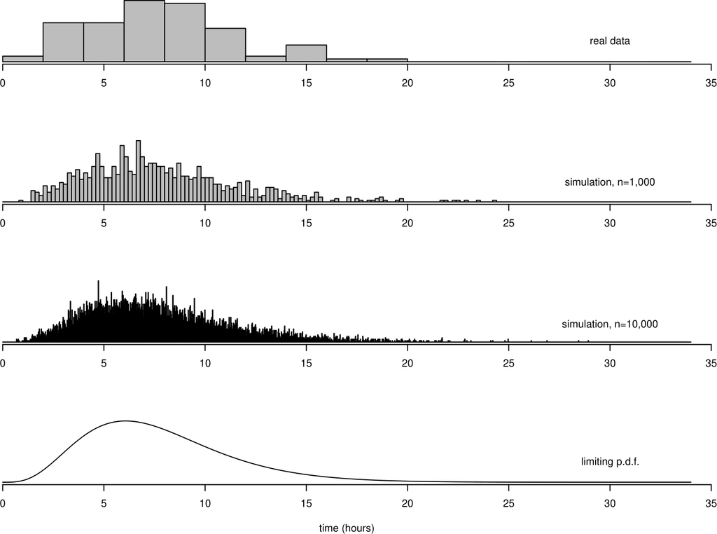

Top: histogram of the Oxford birth durations. Second from top: histogram of 1,000 values simulated from a distribution fitted to the data. Second from bottom: similarly for 10,000 simulated values. Bottom: p.d.f. of the distribution fitted to the Oxford birth times data.

Suppose that we continue to collect data on birth duration from this hospital, and, as new observations arrive, we add them to the top histogram in Figure @ref(fig:oxcontvar). We imagine that the times are recorded continuously. As the number of observations $n$ increases we decrease the bin width of the histogram. As $n$ increases to infinity the bin width shrinks to zero and the histogram tends to a smooth continuous curve.

This is shown in the bottom 3 plots in Figure @ref(fig:oxcontvar). The extra data are not real. They are data I have simulated, using a computer, to have a distribution with a similar shape to the histogram of the real data.

Let $T$ denote the time, in hours, that a woman arriving at the hospital takes to give birth. The smooth continuous curve at the bottom of Figure @ref(fig:oxcontvar) is called the **probability density function (p.d.f.)** $f_T(t)$ of the random variable $T$. Since the total area of the rectangles in a histogram is equal to 1, the area $\int_{-\infty}^{\infty} f_T(t) {\rm ~d}t$ under the p.d.f. $f_T(t)$ is equal to 1.

**Definition**. A **probability density function (p.d.f.)** is a function $f_{X}(x)$, or simply $f(x)$, such that

1. $f_X(x) \geq 0$, for $-\infty < x < \infty$;
2. $\displaystyle\int_{-\infty}^{\infty} f_X(x) {\rm ~d}x = 1$.

Therefore, p.d.f.s are always non-negative and integrate to 1. The support of a continuous random variable is the set of values for which the p.d.f. is positive. Suppose that we wish to find $P(4 < T \leq 12)$. To find the proportion of times between 4 and 12 using a histogram, we sum the areas of all bins between 4 and 12, that is, we find the area shaded in the histogram in Figure @ref(fig:oxshady). To do this using the p.d.f. we do effectively the same thing: we find the area under the p.d.f. $f_T(t)$ between 4 and 12. Since $f_T(t)$ is a smooth continuous curve, (that is, the bin widths are zero) we integrate $f_T(t)$ between 4 and 12.

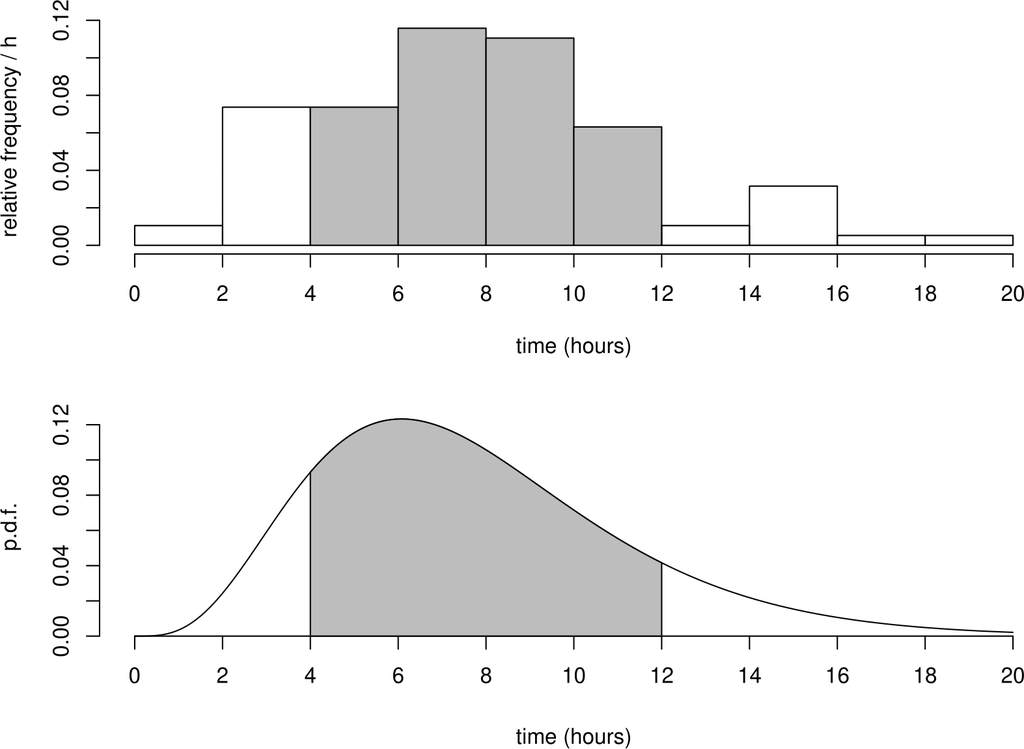

Top: histogram of the Oxford birth durations. Bottom: p.d.f. of the distribution fitted to the Oxford birth duration data.

Therefore
$$P(4 < T \leq 12) = \displaystyle\int_4^{12} f_T(t) {\rm ~d}t = F_T(12)-F_T(4).$$

More generally,
$$P(a < T \leq b) = \displaystyle\int_a^b f_T(t) {\rm ~d}t = F_T(b)-F_T(a).$$

**Definition**. A random variable $X$ is a **continuous random variable** if there exists a p.d.f. $f_X(x)$ such that
$$P(a < X \leq b) = \int_{a}^{b} f_X(x) {\rm ~d}x,$$
for all $a$ and $b$ such that $a < b$.

Figure @ref(fig:pdfshady) illustrates the properties of a p.d.f..

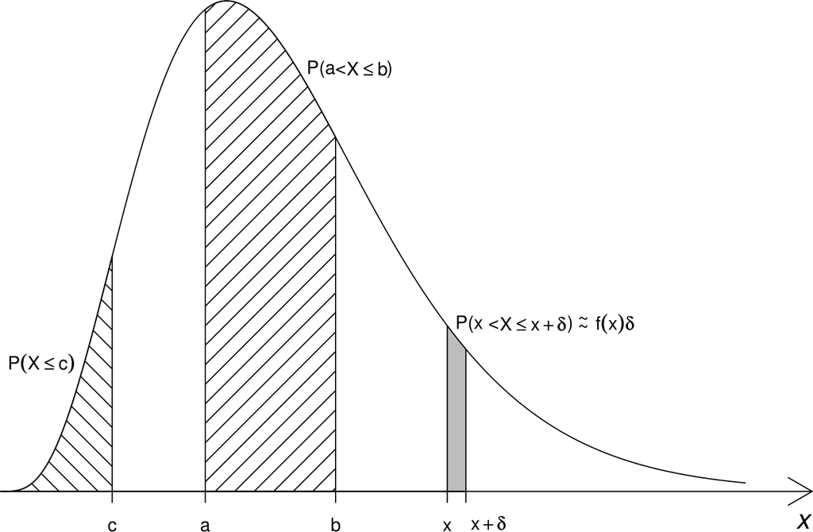

Properties of a p.d.f.. The areas that correspond to the probability that a random variable takes a value in a given interval are shaded.

Notes

- It is very important to appreciate that $f_X(x)$ is **not** a probability: it does **not** give $P(X=x)$. In fact $P(X=x)=0$: the probability that a continuous random variable $X$ takes the value $x$ is zero.
- Indeed, it is possible for a p.d.f. to be greater than 1. Consider a continuous random variable $X$ with p.d.f.
  $$f_X(x) = \left\{ \begin{array}{ll} 2\,(1-x) & \,0 \leq x \leq 1, \\ 0 & \,\mbox{otherwise}.\end{array}\right.$$
  For this random variable $f_X(x)>1$ for any $x \in [0, 1/2)$ .
- Since $P(X=x)=0$
  $$P(a < X \leq b) = P(a \leq X \leq b) = P(a \leq X < b) = P(a < X < b).$$
- $f_X(x)$ is a probability **density**. The probability that $X$ lies in a very small interval of length $\delta$ near $x$ is approximately $f_X(x) \delta$. For the p.d.f. at the bottom of figure @ref(fig:oxcontvar), $f_T(6) > f_T(12)$, indicating that a randomly chosen woman is more likely to spend approximately 6 hours giving birth than approximately 12 hours.

**Relationship between the c.d.f. and p.d.f. of a continuous random variable**. For a continuous random variable
$$F_X(x) = P(X \leq x) = \int_{-\infty}^x f_X(u) {\rm ~d}u.$$
Therefore,
$$f_X(x) = \frac{{\rm d}}{{\rm d}x} F_X(x).$$

## Expectation

The expectation of a random variable is a measure of the location of its distribution.

### Expectation of a discrete random variable

**Example**. We return to the space shuttle example.

Again we consider test flights conducted at a particular temperature, say 53$^\circ$F. Suppose that NASA are able to conduct a very large number $n$ of test flights at 53$^\circ$F, producing a sample $x_1,\ldots,x_n$ of numbers of damaged O-rings.

Let $n(x)$ be the number of test flights on which $x$ of the 6 O-rings were damaged. We can write the sample mean $\bar{x}$ of $x_1,\ldots,x_n$ as
$$\begin{eqnarray*}
\bar{x} &=& \frac{0 \times n(0) + 1 \times n(1) + \cdots + 6 \times n(6)}{n}, \\
&=& \sum_{x=0}^6 x\,\frac{n(x)}{n}.
\end{eqnarray*}$$
As the sample size $n$ increases to infinity, the sample proportion $n(x)/n$ tends to $P(X=x)$, for $x=0,1,\ldots,6$. Therefore, in the limit as $n \rightarrow \infty$, $\bar{x}$ tends to
$$\begin{eqnarray}
\sum_{x=0}^6 x\,P(X=x).
(\#eq:shuttlemean)
\end{eqnarray}$$
This is known as the mean of the probability distribution of $X$. It is a measure of the location of the distribution.

The quantity in equation @ref(eq:shuttlemean) is the value of the sample mean $\bar{x}$ that we would expect to get from a very large sample. Therefore it is often called the **expectation** or **expected value** of the random variable $X$ and it is denoted $\mathrm{E}(X)$.

**Definition**. The **expectation** (or **expected value** or **mean**) $\mathrm{E}(X)$ of a discrete random variable $X$ is given by
$$\begin{eqnarray}
\mathrm{E}(X) &=& \sum_x x\,P(X=x).
(\#eq:discmean)
\end{eqnarray}$$
This is a weighted average of the values that $X$ can take, each value being weighted by $P(X=x)$.

Note:

- We often write $\mu$ or $\mu_X$ for $\mathrm{E}(X)$.
- Units: the units of $\mathrm{E}(X)$ are the same as those of $X$. For example, if $X$ is measured in hours then $\mathrm{E}(X)$ is measured in hours.
- $\mathrm{E}(X)$ exists only if $\sum_x |x|\,P(X=x) < \infty$. If the number of values $X$ can take is finite then $\mathrm{E}(X)$ will always exist.

### Expectation of a continuous random variable

We can define the expectation of a continuous random variable in a similar way to a discrete random variable, replacing summation with integration.

**Definition**. The expectation $\mathrm{E}(X)$ of a continuous random variable $X$ is given by
$$\begin{eqnarray}
\mathrm{E}(X) = \int_{-\infty}^{\infty} x\,f_X(x) {\rm ~d}x.
(\#eq:contmean)
\end{eqnarray}$$
Note:

- Like the discrete case, this is a weighted average of the values that $X$ can take, but now each value is weighted by the p.d.f. $f_X(x)$.
- The range of integration in equation @ref(eq:contmean) is over the whole real line but, in practice, integration will be over the range of possible values of $X$.
- $\mathrm{E}(X)$ exists only if $\int_{-\infty}^{\infty} |x|\,f_X(x) {\rm ~d}x < \infty$.

### Properties of $\mathrm{E}(X)$

If $a$ and $b$ are constants then
$$\mathrm{E}(a\,X+b) = a\,\mathrm{E}(X)+b.$$
This makes sense. If we multiply all observations by $a$ their mean will also be multiplied by $a$. If we add $b$ to all observations their mean will be increased by $b$, that is, the distribution of $X$ shifts up by $b$.

- If $X \geq 0$ then $\mathrm{E}(X) \geq 0$.
- If $X$ is a constant $c$, that is, $P(X=c)=1$ then $\mathrm{E}(X)=c$.
- It can be shown that
  $$\mathrm{E}(X_1 + X_2 + \cdots + X_n) = \mathrm{E}(X_1) + \mathrm{E}(X_2) + \cdots + \mathrm{E}(X_n).$$

### The expectation of $g(X)$

Suppose that $Y=g(X)$ is a function of of $X$, such as $aX+b$, $X^2$ or $\log X$. Then $Y$ is also a random variable. If we find the p.m.f (if $Y$ is discrete) or p.d.f. (if $Y$ is continuous) of $Y$ then we can find the the expectation of $Y$ using equation @ref(eq:discmean) or @ref(eq:contmean) as appropriate.

$$\begin{equation}
\mathrm{E}(Y) = \mathrm{E}[g(X)] =
\begin{cases}
\displaystyle\sum_x g(x)\,P(X=x) & \text{if } X \text{ is discrete}, \\
\int_{-\infty}^{\infty} g(x)\,f_X(x) {\rm ~d}x & \text{if } X \text{ is continuous}.
\end{cases}
(\#eq:expfn)
\end{equation}$$

Note, it is usually the case that
$$\mathrm{E}[g(X)] \neq g[\mathrm{E}(X)]$$
although there are exceptions.

## Variance

The variance of a random variable is a measure of the spread of its distribution.

### Variance of a discrete random variable

**Example**. We return the space shuttle example.

As before we let $n(x)$ be the number of test flights on which $x$ of the 6 O-rings were damaged. We saw in Section @ref(meanstdev) that a measure of the spread of a sample $x_1,\ldots,x_n$ is the sample variance $s_X^2$ which, in this example, can be written as

$$\begin{eqnarray*}
s_X^2 &=& \frac{1}{n-1}\,\left\{
(0-\bar{x})^2\,n(0)+(1-\bar{x})^2\,n(1)+\cdots+(6-\bar{x})^2\,n(6) \right\},
\\
&=& \sum_{x=0}^6 (x-\bar{x})^2\,\frac{n(x)}{n-1}.
\end{eqnarray*}$$
As the sample size $n$ increases to infinity, $\frac{n(x)}{n-1}$ tends to $P(X=x)$, for $x=0,1,\ldots,6$ and $\bar{x}$ tends to $\mu$=$\mathrm{E}(X)$.

Therefore, as $n \rightarrow \infty$, $s_X^2$ tends to

$$\begin{equation}
\sum_{x=0}^6 (x-\mu)^2\,P(X=x).
(\#eq:shuttlevar)
\end{equation}$$

This is known as the variance of the probability distribution of $X$. It is a measure of the spread of the distribution. The quantity in equation @ref(eq:shuttlevar) is the value of the sample variance $s_X^2$ that we would expect to get from a very large sample.

**Definition**. The variance $\mathrm{var}(X)$ of a discrete random variable $X$ with mean $\mathrm{E}(X)=\mu$ is given by

$$\begin{equation}
\mathrm{var}(X) = \sum_x\,(x-\mu)^2\,P(X=x).
(\#eq:varidisc)
\end{equation}$$

This is a weighted average of the squared differences between the values that $X$ can take and its mean $\mu$, each value being weighted by $P(X=x)$.

Note:

- $\mathrm{var}(X)$ exists only if $\mu$ exists and $\sum_x (x-\mu)^2\,P(X=x) < \infty$. If the number of values $X$ can take is finite then $\mathrm{var}(X)$ will always exist.
- We often write $\sigma^2$ or $\sigma_X^2$ for $\mathrm{var}(X)$.

### Variance of a continuous random variable

We can define the variance of a continuous random variable in a similar way to a discrete random variable, replacing summation with integration.

**Definition**. The variance $\mathrm{var}(X)$ of a continuous random variable $X$ with mean $\mathrm{E}(X)=\mu$ is given by

$$\begin{equation}
\mathrm{var}(X) = \int_{-\infty}^{\infty} (x-\mu)^2 f_X(x) {\rm ~d}x.
(\#eq:varicont)
\end{equation}$$

Note: $\mathrm{var}(X)$ exists only if $\mu$ exists and $\int_{-\infty}^{\infty} (x-\mu)^2\,f_X(x) {\rm ~d}x < \infty$.

### Variance and standard deviation

**Definition**. Let $X$ be a random variable with $\mathrm{E}(X)=\mu$. The variance $\mathrm{var}(X)$ is given by
$$\mathrm{var}(X) = \mathrm{E}\left[(X-\mu)^2\right].$$
This follows from equations @ref(eq:varidisc) and @ref(eq:varicont) and the expression in equation @ref(eq:expfn) for the expectation of a function $g(X)$ of a random variable $X$.

There is an alternative way to calculate $\mathrm{var}(X)$:
$$\mathrm{var}(X) = \mathrm{E}\left(X^2\right) - [\mathrm{E}(X)]^2.$$

**Exercise**. Prove this.

**Definition**. The standard deviation sd$(X)$ of $X$ is given by sd($X$)=$+\sqrt{\mathrm{var}(X)}$.

Notes on $\mathrm{var}(X)$:

- $\mathrm{var}(X) \geq 0$. A variance cannot be negative.
- Units: the units of $\mathrm{var}(X)$ are the square of those of $X$. For example, if $X$ is measured in hours then $\mathrm{var}(X)$ is measured in hours$^2$ (and sd($X$) is measured in hours).

### Properties of $\mathrm{var}(X)$

- If $a$ and $b$ are constants then
  $$\mathrm{var}(a\,X+b) = a^2\,\mathrm{var}(X).$$
  This makes sense. If we multiply all observations by $a$ their variance, which is measured square units, will be multiplied by $a^2$. If we add $b$ to all observations their variance will be unchanged because the distribution simply shifts up by $b$ and its spread is unaffected.
- If $X$ is a constant $c$, that is, $P(X=c)=1$ then $\mathrm{var}(X)=0$: the distribution of $X$ has zero spread.
- It can also be shown that **if the random variables $X_1, X_2, \ldots X_n$ are independent** then

$$\begin{equation}
\mathrm{var}(X_1 + X_2 + \cdots + X_n) = \mathrm{var}(X_1) + \mathrm{var}(X_2) + \cdots + \mathrm{var}(X_n).
(\#eq:varsum)
\end{equation}$$

**Note**. Independence is sufficient for this result to hold but it is not necessary. Taking $n=2$ as an example, in generality we have
$$\mathrm{var}(X_1 + X_2) = \mathrm{var}(X_1) + \mathrm{var}(X_2) + 2\,\mathrm{cov}(X_1,X_2),$$
where ${\rm cov}(X_1,X_2)$ is the **covariance** between the random variables $X_1$ and $X_2$. Covariance is a measure of the strength of **linear** association. If $X_1$ and $X_2$ are independent (have no association of any kind) then $\mathrm{cov}(X_1,X_2)=0$, because they have no linear association. However, it is possible for $X_1$ and $X_2$ to be dependent but $\mathrm{cov}(X_1,X_2)=0$, because, although they have some kind of association, they have no **linear** association. Thus, independence is a stronger requirement than zero covariance.

Returing to general $n$ we have
$$\mathrm{var}(X_1 + X_2 + \cdots + X_n) = \mathrm{var}(X_1) + \mathrm{var}(X_2) + \cdots + \mathrm{var}(X_n) + 2 \mathop{\sum\sum}_{i < j} {\rm cov}(X_i,X_j).$$
If $\mathrm{cov}(X_i,X_j)=0$ for all $i < j$ then equation @ref(eq:varsum) holds. We will study covariance, and its standardised form **correlation**, in Section @ref(correlationchapter).

## Other measures of location

### The median of a random variable

Recall that the sample median of a set of observations is the middle observation when the observations are arranged in order of size. We define the median of a random variable $X$ as the value, median($X$), such that

$$P(X < \mathrm{median}(X)) \leq \frac12 \leq P(X \leq \mathrm{median}(X)).$$

In other words, $\mathrm{median}(X)$ is the value where a plot of the c.d.f. $F_X(x)=P(X \leq x)$ crosses $1/2$.

For a continuous random variable $X$ we have
$$F_X(\mathrm{median}(X)) = P(X \leq \mathrm{median}(X)) =\frac12.$$
and the median will divide the distribution into two parts, each with probability 1/2:
$$P(X < \mathrm{median}(X)) = P(X > \mathrm{median}(X)) = \frac12.$$

This will not necessarily hold for a discrete distribution. For example, suppose that
$$P(X=0)=\frac16, \qquad P(X=1)=\frac12, \qquad P(X=2)=\frac13.$$

Then
$$\begin{eqnarray*}
F_X(x) = P(X \leq x) = \left\{\begin{array}{ll}
0 & \mbox{for } x <0, \\
\frac16 & \mbox{for } 0 \leq x < 1, \\
\frac23 & \mbox{for } 1 \leq x < 2, \\
1 & \mbox{for } x \geq 2,
\end{array}\right.
\end{eqnarray*}$$
Therefore, $\mathrm{median}(X) = 1$. However, $P(X<1)=\frac16$ and $P(X>1)=\frac13$.

### The mode of a random variable

Recall that the sample mode of categorical or discrete data is the value (or values) which occurs most often. We define the mode, mode($X$), of a random variable as follows.

For a discrete random variable $X$, the mode is the value which has the highest probability of occurring: $P(X=\mathrm{mode}(X))$ will be larger than for any other value $X$ can have. In other words, $\mathrm{mode}(X)$ is the value at which the p.m.f. is maximised.

For a continuous random variable $X$, the mode is the value at which the p.d.f. is maximised. **If the maximum occurs at a turning point of $f_X(x)$** then it can be found by solving the equation
$$\frac{{\rm d}}{{\rm d}x} f_X(x) = 0,$$
and checking that you have indeed found a maximum.

## Quantiles

To keep things simple we consider a **continuous** random variable $X$. The $100p\%$ quantile of $X$ is defined to be the value $x_p$ such that
$$F_X(x_p)=P(X \leq x_p) = p.$$
Thus, $x_{1/4}$ is the lower quartile of $X$, $x_{1/2}$ is the median of $X$ and $x_{3/4}$ is the upper quartile of $X$. The inter-quartile range is $x_{3/4}-x_{1/4}$.

# Simple distributions

In this section we use a dataset to introduce some commonly-used simple distributions. We will study the **discrete** distributions: Bernoulli, binomial, geometric and Poisson. We will also study the **continuous** distributions: uniform, exponential, normal.

## The Bernoulli distribution

## The binomial distribution

## The geometric distribution

## The Poisson distribution

## The uniform distribution

## The exponential distribution

## The normal distribution

## QQ plots

# Statistical Inference

## Sample and populations

## Probability models

## Fitting models

## Uncertainty in estimation

## What makes an estimator good?

## Assessing goodness-of-fit

# Contingency tables

## 2-way contingency tables

### Comparing probabilities

Note that in Ross, S. (2010) A First Course in Probability the odds ratio of an event $A$ is defined (incorrectly) as $P(A) / (1 - P(A))$. This is a ratio of probabilities. The conventional use of the term **odds ratio** is for a ratio of odds.

## 3-way contingency tables

# Linear regression

## Simple linear regression

## Looking at Scatter plots

## Model checking

### Outliers and influential observations

## Use of transformations

## Over-fitting

## Other aspects of regression

## Uncertainty in parameter estimates

# Correlation

## Correlation: a measure of linear association

## Covariance and correlation

## Use and misuse of correlation

# A general strategy for statistical modelling

# References

Bickel, P. J., E. A. Hammel, and J. W. O’Connell. 1975. “Sex Bias in Graduate Admissions: Data from Berkeley.” *Science* 187 (4175): 398–404. https://doi.org/10.1126/science.187.4175.398.

Dalal, Siddhartha R., Edward B. Fowlkes, and Bruce Hoadley. 1989. “Risk Analysis of the Space Shuttle: Pre-Challenger Prediction of Failure.” *Journal of the American Statistical Association* 84 (408): 945–57. https://doi.org/10.1080/01621459.1989.10478858.

Kerrich, J. E. 1946. *An Experimental Introduction to the Theory of Probability*. E. Munksgaard.

Simpson, Joanne, Anthony Olsen, and Jane C. Eden. 1975. “A Bayesian Analysis of a Multiplicative Treatment Effect in Weather Modification.” *Technometrics* 17 (2): 161–66. https://doi.org/10.1080/00401706.1975.10489297.

Smith, Richard L. 2002. “A Statistical Assessment of Buchanan’s Vote in Palm Beach County.” *Statist. Sci.* 17 (4): 441–57. https://doi.org/10.1214/ss/1049993203.